# W7：機率與樣本的常態性——從描述到推論

心理教育統計 2026

授課教師：陳紹慶 | e-mail: csc2009@mail.tcu.edu.tw

2026/04/13

# 本週學習目標

## 學習成效指標

**哲學意義**：

1. 「描述」與「推論」的本質差異
2. 統計推論是「機率的微光」，沒有絕對的「確定」
3. 常態分佈作為統計模型的核心地位

**工具應用**：

1. 使用 Q-Q Plot 視覺判斷常態性
2. 使用 Shapiro-Wilk 檢定量化常態性
3. 使用 jamovi Compute 功能建立理論百分位

## 對應教材

- 《用 jamovi 上手統計學》
  - [第 7 章：機率](https://scgeeker.github.io/lsj-book-zh_tw/07-Probability.html)
  - [第 9 章：常態分佈](https://scgeeker.github.io/lsj-book-zh_tw/09-Normal-distribution.html)
  - [官方Filter功能說明](https://blog.jamovi.org/2018/04/25/jamovi-filters.html)

**簡報示範資料**：`IQsim`,`aflsmall_margins`

**作業資料**：W04 個人化資料（回頭檢驗 Total_Score 與 RT_ms）

# Part 1：「描述」與「推論」🧠

## 回顧：我們已經學到什麼？

**描述統計**：總結「已經收集到」的資料

- 計算 Mean、SD、Median
- 繪製 Histogram、Box Plot、Violin Plot
- 識別離群值

**本質**：描述**已知**事實

> 「這 100 位學生的平均成績是 *75.3* 分」

## 用已知推測未知

**推論統計**：從「樣本」推測「母群」

- 問題：如果隨機抽一位學生，他的成績**超過 80 分的機率**是多少？
- 工具：**機率分佈模型**
- 關鍵：資料是否符合某個已知的機率分佈（如常態分佈）？

**本質**：**從已知推測未知**

> 「根據這 100 位學生的資料，我們推測下一位學生成績超過 80 分的機率約為 30%」

## 統計推論的不確定性

> **「統計不能提供 100% 的確定性，只能提供機率意義的信號」**
- 我們無法說：「下一位學生**一定**會超過 80 分」
- 我們只能說：「有 30% 的機率超過 80 分」

**為什麼？**

- 樣本不等於母群
- 隨機變異永遠存在
- 我們只能用「**模型**」逼近現實

## 機率分佈：統計推論的基石

**機率分佈**是一種數學模型，描述「所有可能結果的機率」

兩大類機率分佈：

1. **離散機率分佈**：結果是可數的（如：擲骰子、考試答對題數）
2. **連續機率分佈**：結果是連續的（如：身高、體重、考試成績）

**本週焦點**：**常態分佈（Normal Distribution）**

# Part 2：認識常態分佈🧠

## 為何常態分佈如此重要？

**三大理由**：

1. **自然界的普遍模式**：身高、體重、IQ 等許多自然現象都接近常態分佈
2. **中央極限定理（W8重點）**：即使母群不是常態，取樣平均數的分佈也會逼近常態
3. **統計方法的基礎**：許多推論統計方法的*使用前提*（如 t 檢定），都是假設資料符合常態分佈

> **常態分佈是統計推論的「通用語言」**

## 常態分佈的數學形式

**常態分佈由兩個參數決定**：

- **$\mu$（mu，平均數）**：決定鐘型曲線的**中心位置**
- **$\sigma$（sigma，標準差）**：決定鐘型曲線的**胖瘦程度**

**記法**：$X \sim N(\mu, \sigma)$

例如：IQ ~ N(100, 15) 表示樣本的 IQ 分數，符合平均數 100、標準差 15 的常態分佈

## 常態分佈的視覺特徵

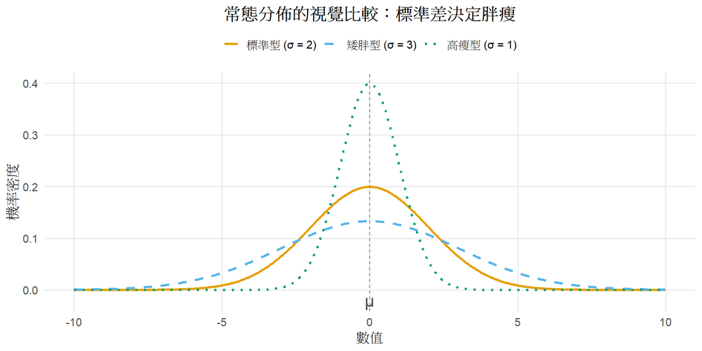

**特性**：

- 對稱：左右兩側完全對稱
- 單峰：只有一個高峰（在 $\mu$ 處）
- 68-95-99.7 法則：68% 資料落在 $\mu \pm 1\sigma$，95% 落在 $\mu \pm 2\sigma$，99.7% 落在 $\mu \pm 3\sigma$

## jamovi 示範：探索 IQsim 資料

**資料說明**：

- `IQsim.omv`：10,000 筆模擬 IQ 分數
- 使用 `NORM(100, 15)` 函數生成（理論完美常態）

**示範步驟**：

1. 開啟 `IQsim.omv`
2. Exploration → Descriptives → 選擇 `IQsim` 變項
3. 查看 Mean、SD、Histogram

**預期結果**：

- Mean ≈ 100, SD ≈ 15
- Histogram 呈現對稱鐘型曲線

# Part 3：樣本資料的常態性檢定🧠👨‍💻

## 問題：現實資料真的是常態嗎？

**理想**：IQsim 是用 NORM 函數生成的，**理論上**完全符合常態分佈

**現實**：大部分真實資料都**不完全符合**常態分佈

- 可能有偏態（左偏或右偏）
- 可能有峰度問題（太尖或太平）
- 可能有離群值

**因此我們需要**：

1. **視覺判斷**：Q-Q Plot
2. **統計檢定**：Shapiro-Wilk Test

## 方法 1：Q-Q Plot（分位數-分位數圖）

**原理**：比較「實際資料的分位數」與「理論常態分佈的分位數」

**解讀規則**：

- **點集中在斜線上** → 資料符合常態分佈
- **點偏離斜線** → 資料不符合常態分佈
  - 左下角翹起：右偏（正偏）
  - 右上角翹起：左偏（負偏）
  - S 型曲線：峰度問題

## jamovi 示範：產生 Q-Q Plot

**操作步驟**：

1. Exploration → Descriptives
2. 示範變項：`IQsim`,`aflsmall_margins`
3. 勾選 **Plots** 區塊：
   - ✓ Q-Q plot

**觀察重點**：

- IQsim 的點是否集中在斜線上？
- LAB重點：個人資料的 `RT_ms`,`Total_Score`

## 方法 2：Shapiro-Wilk 檢定

**原理**：統計檢定資料是否來自常態分佈

**虛無假設（$H_0$）**：資料符合常態分佈

**對立假設（$H_1$）**：資料不符合常態分佈

**判斷規則**：

- **p > 0.05** → 無法拒絕 H₀，資料**可能**符合常態（保守結論）
- **p < 0.05** → 拒絕 H₀，資料**顯著偏離**常態

## jamovi 示範：執行 Shapiro-Wilk 檢定

**操作步驟**：

1. Exploration → Descriptives
2. 示範變項：`IQsim`,`aflsmall_margins`
3. 勾選 **Statistics** 區塊：
   - ✓ Shapiro-Wilk

**結果解讀**：

- W 統計量：越接近 1 越符合常態
- p 值：IQsim 預期 p > 0.05（不能拒絕理論常態性）

## 重要警告：樣本數的影響

**Shapiro-Wilk 檢定的限制**：

- **樣本數小**（N < 50）：不容易檢測出偏離常態（容易漏判）
- **樣本數大**（N > 1000）：非常容易檢測出微小偏離（過度敏感）

**建議**：

- 結合 Q-Q Plot 視覺判斷
- 大樣本的微小偏離不影響後續分析

> **原則**：檢測有無顯著偏離$\neq$符合/不符合常態性

# Part 4：實作 Z 分數🧠👨‍💻

## Z 分數：資料的標準化

**問題**：如何比較不同單位的資料？

- 學生 A：甲氏智力測驗 175 分
- 學生 B：乙氏智力測驗 70 分

**解法**：轉換為「距離平均數幾個標準差」

$$Z = \frac{X - \mu}{\sigma}$$

**Z 分數的意義**：

- Z = 0：正好等於平均數
- Z = 1：比平均數高 1 個標準差
- Z = -2：比平均數低 2 個標準差

## 為何要用 Z 分數？

**統計意義**：資料殘差($X - \bar{X}$)的標準化($S$)

**實用價值**：

- 將不同單位的資料轉換為「標準化分數」
- 判別異常數值（Z > 3 或 Z < -3 通常視為**離群值**）
- 比較不同資料集的相對位置
- 為後續的推論統計做準備

**計算方法**：使用 jamovi 的 **Compute** 功能

## 方法 1：使用內建 Z 函數

**操作步驟**：

1. **Data → Compute**
2. 建立新變數名稱： `IQsim_Z`
3. 輸入公式： `Z(IQsim)`

**這個公式會自動**： - 計算 IQsim 的平均數（$\mu$） - 計算 IQsim 的標準差（$\sigma$） - 套用公式 $Z = \frac{X - \mu}{\sigma}$

## 方法 2：分解計算

1. **計算平均數**（Data → Compute）：
   - 變數名稱：`aflsmall_margins_Mean`
   - 公式：`VMEAN(aflsmall_margins)`
2. **計算標準差**：
   - 變數名稱：`aflsmall_margins_SD`
   - 公式：`VSTDEV(aflsmall_margins)`
3. **手動計算 Z 分數**：
   - 變數名稱：`aflsmall_margins_Z`
   - 公式：`(aflsmall_margins - aflsmall_margins_Mean) / aflsmall_margins_SD`

## 驗證結果

**比較兩種方法**：

- `IQsim_Z`（內建函數）
- `aflsmall_margins_Z`（分解計算）

**預期結果**：用兩種變項的Z分數製作Q-Q plot，只有`IQsim_Z`會逼近**常態分佈**！

**Z 分數分佈的特性**： - 平均數 = 0 - 標準差 = 1 - 範圍大約在 -3 到 +3 之間

## 用Z分數辨識異常數值

**異常數值的判斷準則**（經驗法則）：

- **|Z| > 3**：異常離群值（需特別注意）
- **|Z| > 2.5**：可疑離群值（可考慮排除）
- **|Z| < 2**：正常數值範圍

**jamovi 操作示範**：

1. 建立計算變項`Outlier_Verify`
2. 使用 Filter 功能：`-3 < Z(IQsim) < 3`
3. 使用Frequency Table檢視符合Filter的資料點個數

## Z 分數與常態分佈的關係

**68-95-99.7 法則（用 Z 分數表示）**：

- 68% 資料落在 **Z = -1 到 Z = +1** 之間
- 95% 資料落在 **Z = -2 到 Z = +2** 之間
- 99.7% 資料落在 **Z = -3 到 Z = +3** 之間

**實用意義**：

- 如果你的 Z 分數是 2.5，表示你贏過約 99% 的人
- 如果 Z 分數是 -1.5，表示你輸給約 93% 的人

# Part 5：作業說明

## 作業任務：回頭檢驗你的資料

**目標**：對 W4 的個人化資料進行常態性檢定

**步驟**：

1. 已經檢核討過的 `W04_Lab.omv`，另存為 `W07_Lab.omv`
2. 對 `Total_Score` 和 `RT_ms` 進行常態性檢定：
   - Exploration → Descriptives（Q-Q Plot + Shapiro-Wilk）
3. 計算 Z 分數：
   - 使用**計算變項**/**轉換變項**建立標準化分數

## 繳交要求

**檔案 1：學號_姓名_W07_Lab.omv**

- Descriptives 分析結果（Q-Q Plot + Shapiro-Wilk）
- 包含 Z 分數計算變數（Total_Score_Z、RT_ms_Z）

**檔案 2：學號_姓名_W07_Report.docx**

- 分析結果：置入 Q-Q Plot 與 Shapiro-Wilk 表格
- 報告寫作：以APA寫作格式描述分析結果
- 反思問題（3 題）

**檔案 3：學號_姓名_W07_Score_QQ.png** - 從報表匯出`Total_Score`的Q-Q Plot PNG檔

**檔案 4：學號_姓名_W07_RT_QQ.png** - 從報表匯出`RT_ms`的Q-Q Plot PNG檔

**繳交期限**：本週上課結束前

## 反思問題

1. 從 Q-Q Plot 判斷，你的`RT_ms`與`Total_Score` 是否符合常態分佈？若不符合，是正偏還是負偏？
2. Shapiro-Wilk 檢定結果解讀：你的`RT_ms`與`Total_Score`之 p 值是多少？支持還是反對常態性假設？為什麼？
3. 你認為為什麼現實資料很少符合常態分佈？

# 小結與展望

## 本週核心概念

1. **從描述到推論**：統計推論是「機率的信號」
2. **常態分佈**：自然界最普遍的機率模型
3. **常態性檢定**：
   - 視覺判斷：Q-Q Plot
   - 統計檢定：Shapiro-Wilk
4. **理解原理**：手動建立理論百分位

## 下週預告：中央極限定理

**下週問題**：

- 即使母群不是常態，為何抽樣平均數會趨近常態？
- 樣本數 N 對抽樣分佈有什麼影響？

**示範資料**：繼續使用 IQsim.omv 的抽樣實驗

## 課後資源

**電子書**：

- [第 7 章：機率](https://scgeeker.github.io/lsj-book-zh_tw/07-Probability.html)
- [第 9 章：常態分佈](https://scgeeker.github.io/lsj-book-zh_tw/09-Normal-distribution.html)

**補充論文**（W11 預告）：

Zhang et al. (2025). Watching videos of a drawing hand improves students’ understanding of the normal probability distribution. *Memory & Cognition*. **53**, 262–281. https://doi.org/10.3758/s13421-024-01526-7